# Charity Project - Part 2

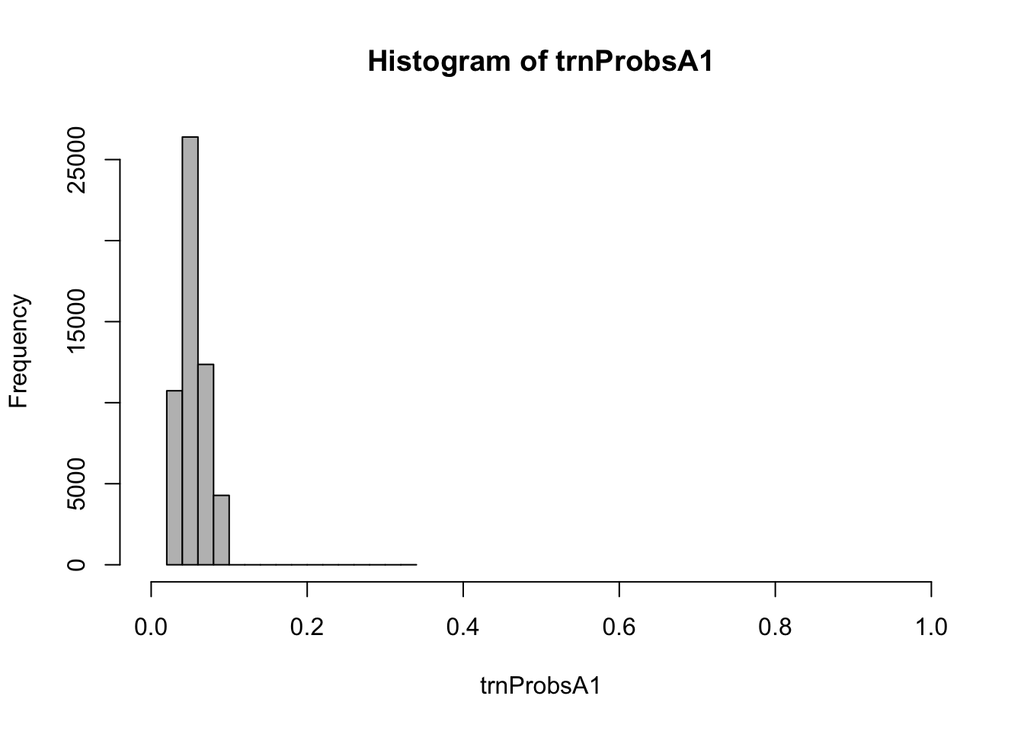

```r
hist(trnProbsA1,col="gray",xlim=c(0,1))   # Rescale to make obvious.
```

```r
# ROC Curve for Model 1 - Use methods from pROC package.
require(pROC)
rocA1 = roc(response=ch.train$DONR,predictor=trnProbsA1)
par(pty="s")  # sets plotting region to a square, useful for ROC curves
# Use par(pty="m") to return to default of rectangular plotting region.
plot(rocA1,col="blue",
     main=paste("ROC curve for Model A1\nAUC = ",round(rocA1$auc,digits=3),sep=""))
```

```
##
## Call:
## roc.default(response = ch.train$DONR, predictor = trnProbsA1)
##
## Data: trnProbsA1 in 50979 controls (ch.train$DONR 0) < 2796 cases (ch.train$DONR 1).
## Area under the curve: 0.5801
```

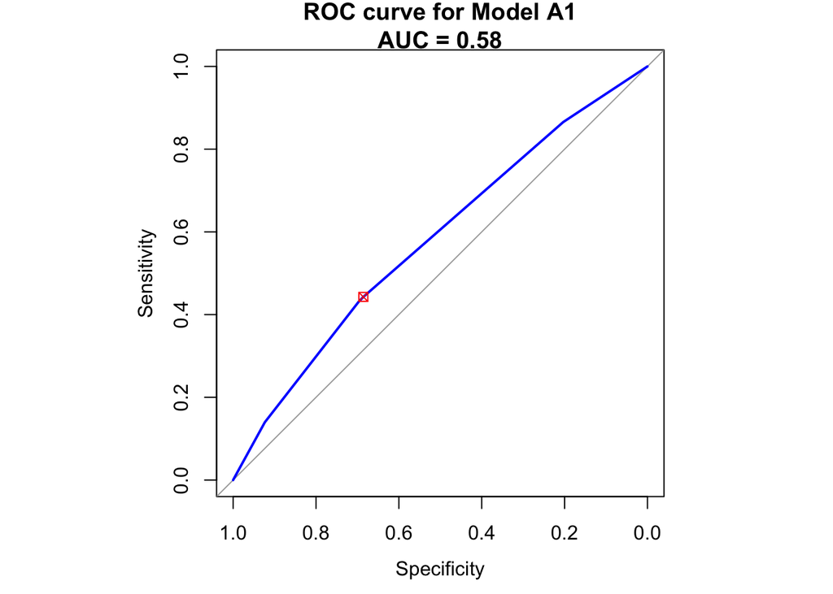

```r
par(pty="m")

# Determine "optimal" threshold.
# Note: There is no single rule to define an "optimal" threshold. We must apply
# our own judgment within the context of the classification problem.
#
# One rule of thumb for determining an optimal point on the ROC curve is to select
# the point closest to the upper-left corner (coordinates (0,1)). This rule gives
# equal weight to TP and FP. We know that is not appropriate in some cases.
# Note: Since the ROC curve is plotted with Specificity on the horizontal axis
# (instead of FP, where FP = 1-Specificity) and the horizontal axis goes
# from 1 down to 0, I will be using the coordinates (1,1) in the distance formula.
dist01 = sqrt((rocA1$specificities-1)^2 + (rocA1$sensitivities-1)^2)
#dist01 = sqrt((0.68*(rocA1$specificities-1))^2 + (15.62*(rocA1$sensitivities-1)^2))
optIdxA1 = which.min(dist01)  # index corresponding to minimum distance
threshA1 = rocA1$thresholds[optIdxA1]  # threshold corresponding to min. distance
points(rocA1$specificities[optIdxA1],rocA1$sensitivities[optIdxA1],col="red",pch=7)
```

```r
threshA1
```

```
## [1] 0.04988464
```

```r
################################### FOR PART 7  a-d  ###################################
glm.probs = predict(glm.fit18, type='response')
max(glm.probs)  #0.333
```

```
## [1] 0.3333333
```

```r
# turn probs into classifications by using 0.5 threshold
glm.pred = ifelse(glm.probs > threshA1, 1, 0)
table(glm.pred, ch.train$DONR)
```

```
##
## glm.pred     0     1
##        0 34959  1558
##        1 16020  1238
```

```r
fit1.train.accuracy = mean(glm.pred==ch.train$DONR)
fit1.train.accuracy   # mean 0.6731195 (training data)
```

```
## [1] 0.6731195
```

```r
# Calculate TP and FP rates
# True positive rate (or sensitivity): TPR=TP/(TP+FN)
fit1.train.tp = 1238/(1238+1558)
fit1.train.tp  # 0.4427754
```

```
## [1] 0.4427754
```

```r
# False positive rate: FPR=FP/(FP+TN)
fit1.train.fp = 16020 / (16020+34959)
fit1.train.fp  #0.314247
```

```
## [1] 0.314247
```

```r
# Create predicted probabilities
glm.probs = predict(glm.fit18, newdata=ch.test, type='response')
glm.pred=ifelse(glm.probs > threshA1, 1, 0)
table(glm.pred,ch.test$DONR)
```

```
##
## glm.pred     0     1
##        0 11669   509
##        1  5368   379
```

```r
fit1.test.accuracy = mean(glm.pred==ch.test$DONR)
fit1.test.accuracy #  mean 0.6721339 (test data)
```

```
## [1] 0.6721339
```

```r
# Calculate TP and FP rates
# True positive rate (or sensitivity): TPR=TP/(TP+FN)
fit1.test.tp = 379/(379+509)
fit1.test.tp  # 0.4268018
```

```
## [1] 0.4268018
```

```r
# False positive rate: FPR=FP/(FP+TN)
fit1.test.fp = 5368 / (5368+11669)
fit1.test.fp  #0.3150789
```

```
## [1] 0.3150789
```

#### MODEL 2: B0 + B1*HOME + B2*MEDHVAL + B3*NUMPROM + B4*NUMPRM12 + B5*TDON + B6*MEDAGE_TRIM + B7*FREQUENCY_97 + B8*AMOUNT_97 + e

```r
#######  NOTE THAT BESTGLM DID NOT WORK --- TO MANY VARIABLE FOR MACBOOK TO CALC  ########
# #install.packages('bestglm')
# library(bestglm)
#
# #subset
# names(ch.train)
# ch.train.reorder = ch.train[,c('HOME','MEDHVAL','MEDEDUC','NUMPROM','NUMPRM12',
#                                'RAMNTALL','NGIFTALL','MAXRAMNT','LASTGIFT',
#                                'TDON','MEDPPH_TRIM','MEDINC_TRIM','FREQUENCY_97',
#                                'AMOUNT_97','RECENCY_96','FREQUENCY_96','AMOUNT_96',
#                                'DONR')]
# res.best.logistic=bestglm(ch.train.reorder, IC='AIC', family=binomial)
#
# ## Show top 5 models
# res.best.logistic$BestModels
#
# ## Show result for the best model: Same model was chosen
# summary(res.best.logistic$BestModel)


#### Let's proceed by running the forward variable selection algorithm:
#    First produce the complete model on all variables.
fullmod = glm(DONR ~ ., data=ch.train, family=binomial)
summary(fullmod)
```

```
##
## Call:
## glm(formula = DONR ~ ., family = binomial, data = ch.train)
##
## Deviance Residuals:
##     Min       1Q   Median       3Q      Max
## -0.9110  -0.3545  -0.3042  -0.2668   2.7988
##
## Coefficients: (2 not defined because of singularities)
##                    Estimate Std. Error z value Pr(>|z|)
## (Intercept)      -8.056e-01  1.270e+00  -0.634  0.52593
## HOME1             9.840e-02  4.237e-02   2.322  0.02021 *
## MEDHVAL           1.207e-04  2.743e-05   4.399 1.09e-05 ***
## MEDEDUC          -6.725e-04  1.656e-03  -0.406  0.68467
## NUMPROM           5.274e-03  2.063e-03   2.557  0.01056 *
## NUMPRM12         -1.650e-02  6.165e-03  -2.677  0.00743 **
## RAMNTALL          2.586e-04  3.412e-04   0.758  0.44853
## NGIFTALL         -5.297e-03  5.032e-03  -1.053  0.29254
## MAXRAMNT          1.477e-03  1.496e-03   0.987  0.32368
## LASTGIFT         -4.406e-03  2.843e-03  -1.550  0.12125
## TDON             -3.440e-02  6.283e-03  -5.475 4.39e-08 ***
## MEDPPH_TRIM      -2.641e-04  5.359e-04  -0.493  0.62207
## MEDAGE_TRIM       5.655e-03  2.881e-03   1.963  0.04964 *
## MEDINC_TRIM       2.677e-04  2.253e-04   1.188  0.23489
## FREQUENCY_972     2.130e-01  1.165e-01   1.828  0.06750 .
## FREQUENCY_973     1.992e-01  1.603e-01   1.242  0.21406
## FREQUENCY_974     5.324e-01  1.978e-01   2.691  0.00712 **
## AMOUNT_97E       -7.324e-01  3.088e-01  -2.372  0.01771 *
## AMOUNT_97F       -7.395e-01  3.253e-01  -2.274  0.02299 *
## AMOUNT_97G       -8.704e-01  4.246e-01  -2.050  0.04038 *
## RECENCY_962      -7.252e-02  1.056e-01  -0.687  0.49207
## RECENCY_963       7.946e-03  2.847e-01   0.028  0.97773
## RECENCY_964       9.990e-02  9.832e-02   1.016  0.30959
## RECENCY_965       1.125e-01  6.071e-02   1.852  0.06396 .
## RECENCY_96None   -1.228e+00  1.273e+00  -0.965  0.33460
## FREQUENCY_962    -8.790e-02  1.196e-01  -0.735  0.46254
## FREQUENCY_963    -1.803e-03  1.603e-01  -0.011  0.99103
## FREQUENCY_964    -1.683e-01  1.969e-01  -0.854  0.39285
## FREQUENCY_96None         NA         NA      NA       NA
## AMOUNT_962       -1.666e+00  1.436e+00  -1.160  0.24624
## AMOUNT_963       -1.651e+00  1.229e+00  -1.343  0.17937
## AMOUNT_964       -1.117e+00  1.267e+00  -0.882  0.37791
## AMOUNT_965       -1.293e+00  1.270e+00  -1.018  0.30854
## AMOUNT_966       -1.476e+00  1.299e+00  -1.136  0.25583
## AMOUNT_96None            NA         NA      NA       NA
## ---
## Signif. codes:  0 '***' 0.001 '**' 0.01 '*' 0.05 '.' 0.1 ' ' 1
##
## (Dispersion parameter for binomial family taken to be 1)
##
##     Null deviance: 21977  on 53774  degrees of freedom
## Residual deviance: 21532  on 53742  degrees of freedom
## AIC: 21598
##
## Number of Fisher Scoring iterations: 6
```

```r
# Significant variables at 0.1%: MEDHVAL, TDON
# Significant variables at 1%  : NUMPRM12, FREQUENCY_974
# Significant variables at 5%  : HOME, NUMPROM, MEDAGE_TRIM, AMOUNT_97E,AMOUNT_97F,AMOUNT_97G

# Run forward variable selection algorithm:
nothing = glm(DONR ~ 1,data=ch.train,family=binomial)
forwards = step(nothing, scope=list(lower=formula(nothing),upper=formula(fullmod)), direction="forward")
```

```
## Start:  AIC=21979.45
## DONR ~ 1
```

```
##                Df Deviance   AIC
## + AMOUNT_97     3    21726 21734
## + AMOUNT_96     6    21730 21744
## + FREQUENCY_97  3    21758 21766
## + FREQUENCY_96  4    21781 21791
## + LASTGIFT      1    21830 21834
## + RECENCY_96    5    21837 21849
## + NGIFTALL      1    21867 21871
## + TDON          1    21892 21896
## + MAXRAMNT      1    21920 21924
## + NUMPROM       1    21924 21928
## + MEDHVAL       1    21944 21948
## + MEDINC_TRIM   1    21960 21964
## + NUMPRM12      1    21966 21970
## + MEDAGE_TRIM   1    21966 21970
## + MEDEDUC       1    21969 21973
## + RAMNTALL      1    21970 21974
## + HOME          1    21974 21978
## <none>               21977 21979
## + MEDPPH_TRIM   1    21977 21981
##
## Step:  AIC=21734.43
## DONR ~ AMOUNT_97
##
##                Df Deviance   AIC
## + MEDHVAL       1    21670 21680
## + TDON          1    21673 21683
## + FREQUENCY_97  3    21672 21686
## + FREQUENCY_96  4    21685 21701
## + MEDINC_TRIM   1    21692 21702
## + RECENCY_96    5    21693 21711
## + NUMPROM       1    21706 21716
## + RAMNTALL      1    21707 21717
## + MEDEDUC       1    21708 21718
## + NGIFTALL      1    21708 21718
## + NUMPRM12      1    21712 21722
## + MEDAGE_TRIM   1    21718 21728
## + HOME          1    21721 21731
## + LASTGIFT      1    21724 21734
## <none>               21726 21734
```

[output cut: 124 more lines]

```
## DONR ~ AMOUNT_97 + MEDHVAL + TDON + FREQUENCY_97 + NUMPROM +
##     NUMPRM12 + HOME + MEDAGE_TRIM
##
##                Df Deviance   AIC
## <none>               21549 21575
## + MEDINC_TRIM   1    21548 21576
## + LASTGIFT      1    21548 21576
## + MAXRAMNT      1    21549 21577
## + RAMNTALL      1    21549 21577
## + NGIFTALL      1    21549 21577
## + MEDEDUC       1    21549 21577
## + MEDPPH_TRIM   1    21549 21577
## + FREQUENCY_96  4    21547 21581
## + RECENCY_96    5    21545 21581
## + AMOUNT_96     6    21544 21582
```

```r
summary(forwards)
```

```
##
## Call:
## glm(formula = DONR ~ AMOUNT_97 + MEDHVAL + TDON + FREQUENCY_97 +
##     NUMPROM + NUMPRM12 + HOME + MEDAGE_TRIM, family = binomial,
##     data = ch.train)
##
## Deviance Residuals:
##     Min       1Q   Median       3Q      Max
## -0.7353  -0.3544  -0.3048  -0.2677   2.7949
##
## Coefficients:
##                 Estimate Std. Error z value Pr(>|z|)
## (Intercept)   -2.608e+00  2.059e-01 -12.667  < 2e-16 ***
## AMOUNT_97E    -2.084e-01  7.199e-02  -2.895 0.003796 **
## AMOUNT_97F    -3.833e-01  8.059e-02  -4.756 1.98e-06 ***
## AMOUNT_97G    -7.113e-01  9.137e-02  -7.784 7.02e-15 ***
## MEDHVAL        1.429e-04  1.881e-05   7.599 2.99e-14 ***
## TDON          -3.440e-02  6.021e-03  -5.714 1.11e-08 ***
## FREQUENCY_972  1.944e-01  5.295e-02   3.671 0.000242 ***
## FREQUENCY_973  2.490e-01  6.274e-02   3.968 7.25e-05 ***
## FREQUENCY_974  4.429e-01  7.063e-02   6.271 3.58e-10 ***
## NUMPROM        5.295e-03  1.074e-03   4.930 8.21e-07 ***
## NUMPRM12      -1.697e-02  5.754e-03  -2.950 0.003179 **
## HOME1          1.032e-01  4.187e-02   2.465 0.013697 *
## MEDAGE_TRIM    6.029e-03  2.647e-03   2.277 0.022763 *
## ---
## Signif. codes:  0 '***' 0.001 '**' 0.01 '*' 0.05 '.' 0.1 ' ' 1
##
## (Dispersion parameter for binomial family taken to be 1)
##
##     Null deviance: 21977  on 53774  degrees of freedom
## Residual deviance: 21549  on 53762  degrees of freedom
## AIC: 21575
##
## Number of Fisher Scoring iterations: 6
```

```r
# re-writing lowest AIC 21574.97 model from the forward variable selection algorithm:
glm.fwd = glm(DONR ~ AMOUNT_97 + MEDHVAL + TDON + FREQUENCY_97 + NUMPROM + NUMPRM12 + HOME + MEDAGE_TRIM, data=ch.train, family=binomial)

# Model from Forward variable selection
# Step:  AIC=21574.97
# DONR ~ AMOUNT_97 + MEDHVAL + TDON + FREQUENCY_97 + NUMPROM +
#     NUMPRM12 + HOME + MEDAGE_TRIM
#
#                Df Deviance   AIC
# <none>               21549 21575
# + MEDINC_TRIM   1    21548 21576
# + LASTGIFT      1    21548 21576
# + MAXRAMNT      1    21549 21577
# + RAMNTALL      1    21549 21577
# + NGIFTALL      1    21549 21577
# + MEDEDUC       1    21549 21577
# + MEDPPH_TRIM   1    21549 21577
# + FREQUENCY_96  4    21547 21581
# + RECENCY_96    5    21545 21581
# + AMOUNT_96     6    21544 21582


# Run backward variable selection algorithm
backwards = step(fullmod) # Backwards selection is the default
```

```
## Start:  AIC=21597.98
## DONR ~ HOME + MEDHVAL + MEDEDUC + NUMPROM + NUMPRM12 + RAMNTALL +
##     NGIFTALL + MAXRAMNT + LASTGIFT + TDON + MEDPPH_TRIM + MEDAGE_TRIM +
##     MEDINC_TRIM + FREQUENCY_97 + AMOUNT_97 + RECENCY_96 + FREQUENCY_96 +
##     AMOUNT_96
##
##                Df Deviance   AIC
## - AMOUNT_96     5    21537 21593
## - FREQUENCY_96  3    21534 21594
## - RECENCY_96    4    21537 21595
## - MEDEDUC       1    21532 21596
## - MEDPPH_TRIM   1    21532 21596
## - RAMNTALL      1    21532 21596
## - MAXRAMNT      1    21533 21597
## - NGIFTALL      1    21533 21597
## - MEDINC_TRIM   1    21533 21597
## <none>               21532 21598
## - LASTGIFT      1    21535 21599
## - AMOUNT_97     3    21539 21599
## - MEDAGE_TRIM   1    21536 21600
## - HOME          1    21537 21601
## - FREQUENCY_97  3    21542 21602
## - NUMPROM       1    21539 21603
## - NUMPRM12      1    21539 21603
## - MEDHVAL       1    21551 21615
## - TDON          1    21562 21626
##
## Step:  AIC=21593.29
## DONR ~ HOME + MEDHVAL + MEDEDUC + NUMPROM + NUMPRM12 + RAMNTALL +
##     NGIFTALL + MAXRAMNT + LASTGIFT + TDON + MEDPPH_TRIM + MEDAGE_TRIM +
##     MEDINC_TRIM + FREQUENCY_97 + AMOUNT_97 + RECENCY_96 + FREQUENCY_96
##
##                Df Deviance   AIC
## - FREQUENCY_96  3    21540 21590
## - RECENCY_96    4    21542 21590
## - MEDEDUC       1    21537 21591
## - MEDPPH_TRIM   1    21538 21592
## - RAMNTALL      1    21538 21592
## - MAXRAMNT      1    21538 21592
## - NGIFTALL      1    21538 21592
```

[output cut: 172 more lines]

```
##
## Step:  AIC=21574.97
## DONR ~ HOME + MEDHVAL + NUMPROM + NUMPRM12 + TDON + MEDAGE_TRIM +
##     FREQUENCY_97 + AMOUNT_97
##
##                Df Deviance   AIC
## <none>               21549 21575
## - MEDAGE_TRIM   1    21554 21578
## - HOME          1    21555 21579
## - NUMPRM12      1    21558 21582
## - NUMPROM       1    21573 21597
## - TDON          1    21581 21605
## - FREQUENCY_97  3    21590 21610
## - MEDHVAL       1    21602 21626
## - AMOUNT_97     3    21624 21644
```

```r
# Step:  AIC=21574.97
# DONR ~ HOME + MEDHVAL + NUMPROM + NUMPRM12 + TDON + MEDAGE_TRIM +
#     FREQUENCY_97 + AMOUNT_97
#
#                Df Deviance   AIC
# <none>               21549 21575
# - MEDAGE_TRIM   1    21554 21578
# - HOME          1    21555 21579
# - NUMPRM12      1    21558 21582
# - NUMPROM       1    21573 21597
# - TDON          1    21581 21605
# - FREQUENCY_97  3    21590 21610
# - MEDHVAL       1    21602 21626
# - AMOUNT_97     3    21624 21644


# Run stepwise variable seletion algorithm
bothways = step(nothing, list(lower=formula(nothing),upper=formula(fullmod)), direction="both", trace=0)
```

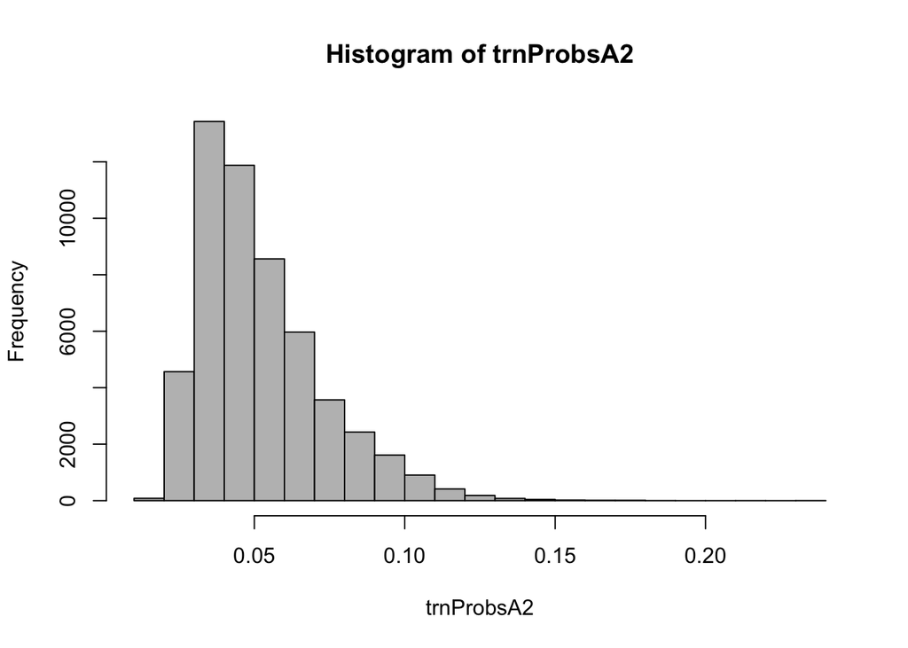

```r
# Step:  AIC=21574.97
# DONR ~ AMOUNT_97 + MEDHVAL + TDON + FREQUENCY_97 + NUMPROM +
#     NUMPRM12 + HOME + MEDAGE_TRIM


glm.stepwise = glm(DONR~AMOUNT_97 + MEDHVAL + TDON + FREQUENCY_97 + NUMPROM + NUMPRM12 + HOME + MEDAGE_TRIM, data=ch.train, family=binomial)


######## For PART 7  a-d
# As observed in EDA, the DONR=1 class represents approximately 5%
# of the dataset. This explains why the logistic regression scores are on the scale
# of 0.05. As such, using the default cutoff of 0.5 would result in all individuals
# being classified as non-donors. While this would be a very unhelpful classifcation
# model, it would have 95% accuracy since the model would be incorrect only 5% of
# the time.
trnProbsA2 = predict(glm.stepwise,type="response")
hist(trnProbsA2,col="gray")   # Note that scores are distributed around 0.05.
```

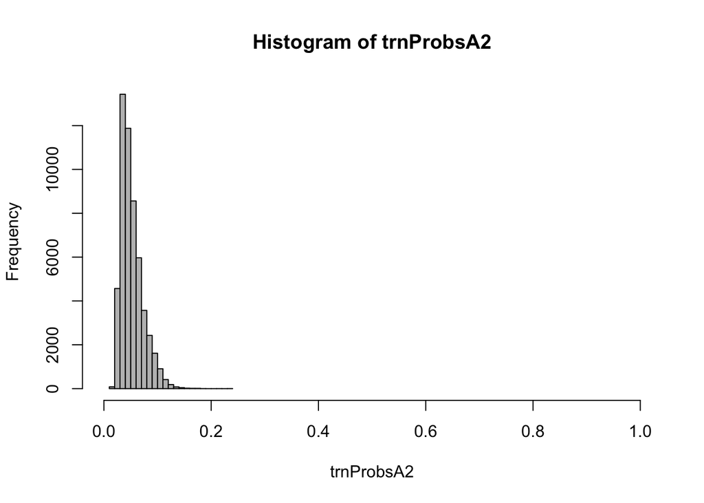

```r
hist(trnProbsA2,col="gray",xlim=c(0,1))   # Rescale to make obvious.
```

```r
# ROC Curve for Model 2 - Use methods from pROC package.
rocA2 = roc(response=ch.train$DONR,predictor=trnProbsA2)
par(pty="s")  # sets plotting region to a square, useful for ROC curves
# Use par(pty="m") to return to default of rectangular plotting region.
plot(rocA2,col="blue",
     main=paste("ROC curve for Model 2\nAUC = ",round(rocA2$auc,digits=3),sep=""))
```

```
##
## Call:
## roc.default(response = ch.train$DONR, predictor = trnProbsA2)
##
## Data: trnProbsA2 in 50979 controls (ch.train$DONR 0) < 2796 cases (ch.train$DONR 1).
## Area under the curve: 0.6121
```

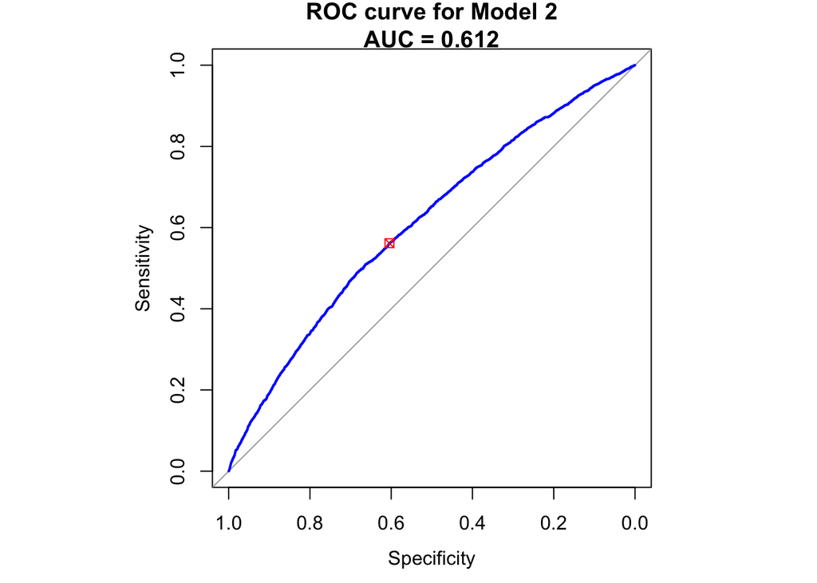

```r
par(pty="m")

# Determine "optimal" threshold.
# One rule of thumb for determining an optimal point on the ROC curve is to select
# the point closest to the upper-left corner (coordinates (0,1)). This rule gives
# equal weight to TP and FP. We know that is not appropriate in some cases.
# Note: Since the ROC curve is plotted with Specificity on the horizontal axis
# (instead of FP, where FP = 1-Specificity) and the horizontal axis goes
# from 1 down to 0, I will be using the coordinates (1,1) in the distance formula.
dist01 = sqrt((rocA2$specificities-1)^2 + (rocA2$sensitivities-1)^2)
optIdxA2 = which.min(dist01)  # index corresponding to minimum distance
threshA2 = rocA2$thresholds[optIdxA2]  # threshold corresponding to min. distance
points(rocA2$specificities[optIdxA2],rocA2$sensitivities[optIdxA2],col="red",pch=7)
```

```r
threshA2
```

```
## [1] 0.05218361
```

```r
# Create predicted probabilities for the stepwise model 2
glm.probs = predict(glm.stepwise, type='response')
max(glm.probs)  #0.2368888
```

```
## [1] 0.2368888
```

```r
# turn probs into classifications by using optimum threshold calculated above
glm.pred = ifelse(glm.probs > threshA2, 1, 0)
table(glm.pred, ch.train$DONR)
```

```
##
## glm.pred     0     1
##        0 30807  1226
##        1 20172  1570
```

```r
fit2.train.accuracy = mean(glm.pred==ch.train$DONR)
fit2.train.accuracy   # mean 0.6020828 (on training data)
```

```
## [1] 0.6020828
```

```r
# Calculate TP and FP rates
# True positive rate (or sensitivity): TPR=TP/(TP+FN)
fit2.train.tp = 1570/(1570+1226)
fit2.train.tp  # 0.5615165
```

```
## [1] 0.5615165
```

```r
# False positive rate: FPR=FP/(FP+TN)
fit2.train.fp = 20172 / (20172+30807)
fit2.train.fp  #0.3956923
```

```
## [1] 0.3956923
```

```r
# Create predicted probabilities
glm.probs = predict(glm.stepwise, newdata=ch.test, type='response')
glm.pred=ifelse(glm.probs > threshA2, 1, 0)
table(glm.pred,ch.test$DONR)
```

```
##
## glm.pred     0     1
##        0 10241   390
##        1  6796   498
```

```r
fit2.test.accuracy = mean(glm.pred==ch.test$DONR)
fit2.test.accuracy #  mean 0.5991074 (test data)
```

```
## [1] 0.5991074
```

```r
# Calculate TP and FP rates
# True positive rate (or sensitivity): TPR=TP/(TP+FN)
fit2.test.tp = 498/(498+390)
fit2.test.tp  # 0.5608108
```

```
## [1] 0.5608108
```

```r
# False positive rate: FPR=FP/(FP+TN)
fit2.test.fp = 6796 / (6796+10241)
fit2.test.fp  #0.3988965
```

```
## [1] 0.3988965
```

#### MODEL 3 - Decision Tree

On an initial run of the decision-tree algorithm using the tree() library a single node tree was produced. I.e. the fitted tree determineD that the best selection of nodes was simply to select all observations falling under DONR=0 to minimize the errors. Therefore, we reproduce the output using the rpart() library so that the creation of nodes is forced upon the training data.

```r
## Part C - Tree-Based Models
# A few notes about fitting a classification tree to the charity data.
#  1) tree(DONR ~ .-ID,data=classData2,subset=trainIdx) gives you a single node tree
#  This is not desirable for a classification model. Basically, every individual is
#  labelled a non-donor (as with logistic regression and a cutoff of 0.5).
#  2) One thing we can do to result in the tree method building more
#  than a single node tree, is set split="gini". See pp. 311-12 of ISLR for
#  discussion of the Gini index.
#  3) When we set split="gini", we next get an error that maximum tree depth has
#  been reached. We can ameliorate this error by selecting fewer variables in the
#  model formula (I started with DONR ~ .-ID). I believe this error results from
#  limitations in the way the tree method is implemented.
#  4) Having said all that, with the formula
#     DONR ~  NGIFTALL + MAXRAMNT + LASTGIFT + TDON
#  I got a tree with 2185 nodes. When I tried to run cv.tree to look at pruning
#  the tree, I got an error about a singlenode tree that I was unable to resolve.
#  5) The tree package is not the most widely used package for building trees; rpart
#  is much more common. Therefore, I am switching to using the rpart package.
#  6) The rpart method requires some parameter settings in order for it to build
#  a tree of more than a single node. The parameters are:
#     method="class" (should be the default setting when DONR is a factor variable,
#       but at this point it doesn't hurt to be explicit)
#     split="gini" (same as with the tree method)
#     loss=matrix(0,15.62,0.68,0) (sets cost parameters: $0.68 for FP and $15.62
#       for FN)
require(rpart)
fullTree = rpart(DONR ~  .,
                data=ch.train,method="class",
                parms=list(split="gini",loss=matrix(c(0,15.62,0.68,0),nrow=2,ncol=2)))
summary(fullTree)
```

```
## Call:
## rpart(formula = DONR ~ ., data = ch.train, method = "class",
##     parms = list(split = "gini", loss = matrix(c(0, 15.62, 0.68,
##         0), nrow = 2, ncol = 2)))
##   n= 53775
##
##           CP nsplit rel error   xerror       xstd
## 1 0.02660784      0 1.0000000 22.97059 0.02319823
## 2 0.01000000      2 0.9467843 14.44256 0.05120972
##
## Variable importance
##    AMOUNT_97    AMOUNT_96     MAXRAMNT     LASTGIFT FREQUENCY_97
##           20           20           17           16            7
## FREQUENCY_96      MEDHVAL  MEDINC_TRIM      MEDEDUC  MEDPPH_TRIM
##            7            6            3            3            1
##
## Node number 1: 53775 observations,    complexity param=0.02660784
##   predicted class=1  expected loss=0.6446438  P(node) =1
##     class counts: 50979  2796
##    probabilities: 0.948 0.052
##   left son=2 (37285 obs) right son=3 (16490 obs)
##   Primary splits:
##       AMOUNT_97    splits as  RRLL,       improve=460.2314, (0 missing)
##       AMOUNT_96    splits as  RRRRLLL,    improve=458.4921, (0 missing)
##       LASTGIFT     < 14.35  to the right, improve=415.5570, (0 missing)
##       MAXRAMNT     < 14.5   to the right, improve=401.8433, (0 missing)
##       FREQUENCY_97 splits as  LRRR,       improve=398.6758, (0 missing)
##   Surrogate splits:
##       AMOUNT_96    splits as  RRRRLLL,    agree=0.991, adj=0.971, (0 split)
##       MAXRAMNT     < 14.5   to the right, agree=0.947, adj=0.827, (0 split)
##       LASTGIFT     < 14.35  to the right, agree=0.936, adj=0.793, (0 split)
##       FREQUENCY_97 splits as  LLRR,       agree=0.807, adj=0.370, (0 split)
##       FREQUENCY_96 splits as  LLRRL,      agree=0.799, adj=0.344, (0 split)
##
## Node number 2: 37285 observations,    complexity param=0.02660784
##   predicted class=1  expected loss=0.6508376  P(node) =0.6933519
##     class counts: 35686  1599
##    probabilities: 0.957 0.043
##   left son=4 (19732 obs) right son=5 (17553 obs)
##   Primary splits:
```

[output cut: 11 more lines]

```
##
## Node number 3: 16490 observations
##   predicted class=1  expected loss=0.6306392  P(node) =0.3066481
##     class counts: 15293  1197
##    probabilities: 0.927 0.073
##
## Node number 4: 19732 observations
##   predicted class=0  expected loss=0.5620414  P(node) =0.3669363
##     class counts: 19022   710
##    probabilities: 0.964 0.036
##
## Node number 5: 17553 observations
##   predicted class=1  expected loss=0.6455603  P(node) =0.3264156
##     class counts: 16664   889
##    probabilities: 0.949 0.051
```

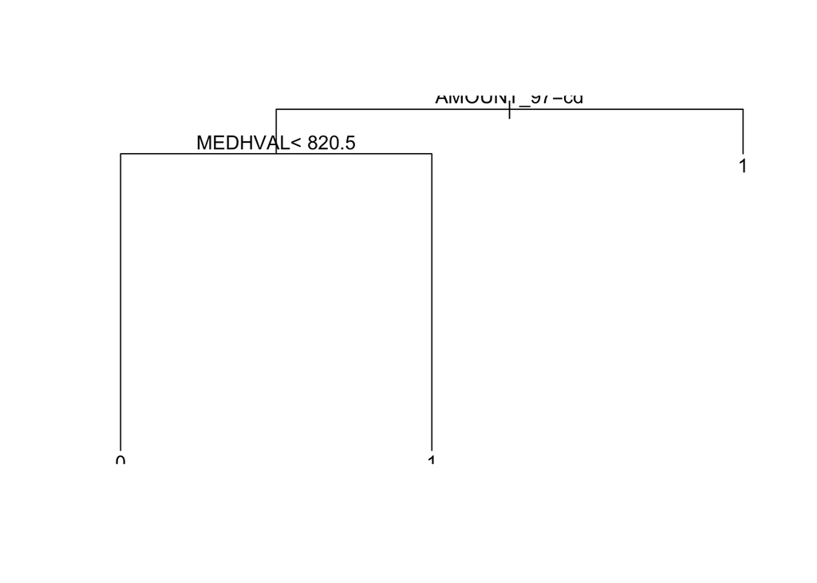

```r
plot(fullTree)
text(fullTree)
```

```r
# PART 7 a-d
# Calculate TP and FP rates
# We do not need a ROC curve for a classification tree. The tree provides the
# classification results directly.
tree.pred=predict(fullTree, ch.train,type='class')
with(ch.train,table(tree.pred, ch.train$DONR))
```

```
##
## tree.pred     0     1
##         0 19022   710
##         1 31957  2086
```

```r
fit3.train.accuracy = (19022+2086)/53775
fit3.train.accuracy  # 0.3925244
```

```
## [1] 0.3925244
```

```r
# True positive rate (or sensitivity): TPR=TP/(TP+FN)
fit3.train.tp = 2086/(2086+710)
fit3.train.tp  # 0.7460658
```

```
## [1] 0.7460658
```

```r
# False positive rate: FPR=FP/(FP+TN)
fit3.train.fp = 31957 / (31957+19022)
fit3.train.fp  #0.626866
```

```
## [1] 0.626866
```

```r
# repeat exercise for the test data set tp and fp rates
tree.pred=predict(fullTree, ch.test,type='class')
with(ch.test,table(tree.pred, ch.test$DONR))
```

```
##
## tree.pred     0     1
##         0  6412   232
##         1 10625   656
```

```r
fit3.test.accuracy = (6412+656)/17925
fit3.test.accuracy # 0.3943096
```

```
## [1] 0.3943096
```

```r
# True positive rate (or sensitivity): TPR=TP/(TP+FN)
fit3.test.tp = 656/(656+232)
fit3.test.tp  # 0.7387387
```

```
## [1] 0.7387387
```

```r
# False positive rate: FPR=FP/(FP+TN)
fit3.test.fp = 10625 / (10625+6412)
fit3.test.fp  #0.6236427
```

```
## [1] 0.6236427
```

#### d. Linear Discriminant Analysis

#### MODEL 4

```r
# Linear Discriminant Analysis
library(MASS)
lda.fit = lda(DONR~., data=ch.train)
lda.fit
```

```
## Call:
## lda(DONR ~ ., data = ch.train)
##
## Prior probabilities of groups:
##          0          1
## 0.94800558 0.05199442
##
## Group means:
##       HOME1  MEDHVAL  MEDEDUC  NUMPROM NUMPRM12 RAMNTALL  NGIFTALL
## 0 0.6592322 1055.455 128.5145 48.37406 12.93574 107.2838  9.803821
## 1 0.6752504 1163.768 129.4607 51.60944 13.24356 113.5737 11.631259
##   MAXRAMNT LASTGIFT     TDON MEDPPH_TRIM MEDAGE_TRIM MEDINC_TRIM
## 0 19.95747 17.38248 18.41902    186.8146    42.19645    344.0561
## 1 18.11836 14.98882 17.69778    185.9914    42.67554    356.6924
##   FREQUENCY_972 FREQUENCY_973 FREQUENCY_974 AMOUNT_97E AMOUNT_97F
## 0     0.2205026     0.1572608     0.1160282  0.2264070  0.4930462
## 1     0.2267525     0.1981402     0.1913448  0.2893419  0.4338340
##   AMOUNT_97G RECENCY_962 RECENCY_963 RECENCY_964 RECENCY_965
## 0  0.2069676  0.07781636 0.005570921  0.05712156    0.203319
## 1  0.1380544  0.05150215 0.005007153  0.05150215    0.295422
##   RECENCY_96None FREQUENCY_962 FREQUENCY_963 FREQUENCY_964
## 0     0.01135762     0.2230134     0.1499049     0.1113203
## 1     0.01180258     0.2274678     0.1956366     0.1766810
##   FREQUENCY_96None   AMOUNT_962 AMOUNT_963 AMOUNT_964 AMOUNT_965
## 0       0.01135762 0.0004707821 0.07634516  0.2260342  0.4825320
## 1       0.01180258 0.0007153076 0.13912732  0.2907725  0.4227468
##   AMOUNT_966 AMOUNT_96None
## 0  0.2032209    0.01135762
## 1  0.1344778    0.01180258
##
## Coefficients of linear discriminants:
##                            LD1
## HOME1             2.256871e-01
## MEDHVAL           3.254818e-04
## MEDEDUC          -2.021134e-03
## NUMPROM           1.186179e-02
## NUMPRM12         -3.501248e-02
## RAMNTALL          5.238333e-05
## NGIFTALL         -7.741920e-03
## MAXRAMNT          7.283107e-03
```

[output cut: 11 more lines]

```
## RECENCY_962      -1.032021e-01
## RECENCY_963       2.043779e-02
## RECENCY_964       2.433113e-01
## RECENCY_965       3.580862e-01
## RECENCY_96None   -3.524663e+00
## FREQUENCY_962    -2.597628e-01
## FREQUENCY_963    -8.134938e-02
## FREQUENCY_964    -7.419945e-01
## FREQUENCY_96None -3.524663e+00
## AMOUNT_962       -1.176915e+01
## AMOUNT_963       -1.171883e+01
## AMOUNT_964       -1.026050e+01
## AMOUNT_965       -1.071605e+01
## AMOUNT_966       -1.100259e+01
## AMOUNT_96None    -3.524663e+00
```

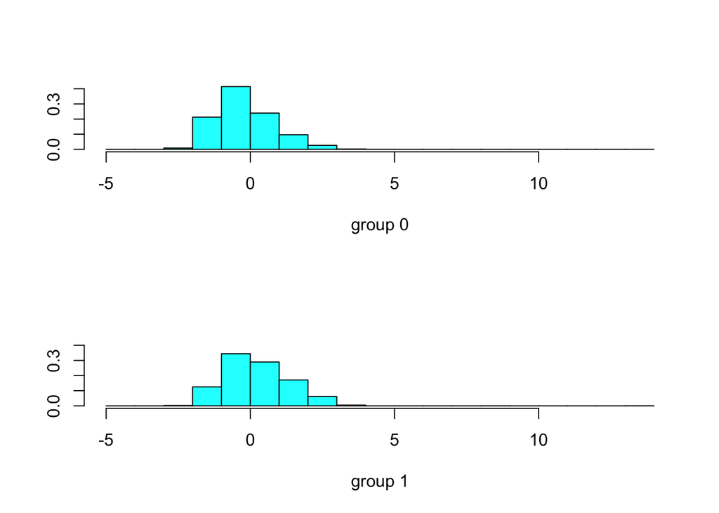

```r
plot(lda.fit)
```

```r
# PART 7 a-d
lda.pred = predict(lda.fit, ch.train)
table(lda.pred$class,ch.train$DONR) # is the confusion matrix
```

```
##
##         0     1
##   0 50977  2794
##   1     2     2
```

```r
mean(lda.pred$class==ch.train$DONR) # 0.9480056 - correct classification of 1/0
```

```
## [1] 0.9480056
```

```r
fit4.train.accuracy = mean(lda.pred$class==ch.train$DONR)
fit4.train.accuracy  # 0.9480056 - training
```

```
## [1] 0.9480056
```

```r
# True positive rate (or sensitivity): TPR=TP/(TP+FN)
fit4.train.tp = 2 / (2+2794)
fit4.train.tp # 0.0007153076
```

```
## [1] 0.0007153076
```

```r
# False positive rate: FPR=FP/(FP+TN)
fit4.train.fp = 2 / (2+50977)
fit4.train.fp
```

```
## [1] 3.923184e-05
```

```r
lda.pred = predict(lda.fit, ch.test)
table(lda.pred$class,ch.test$DONR) # is the confusion matrix
```

```
##
##         0     1
##   0 17036   888
##   1     1     0
```

```r
mean(lda.pred$class==ch.test$DONR) # 0.9504045 - correct classification of 1/0
```

```
## [1] 0.9504045
```

```r
fit4.test.accuracy = mean(lda.pred$class==ch.test$DONR)
fit4.test.accuracy                # 0.9504045
```

```
## [1] 0.9504045
```

```r
# True positive rate (or sensitivity): TPR=TP/(TP+FN)
fit4.test.tp = 0 / 888
fit4.test.tp
```

```
## [1] 0
```

```r
# False positive rate: FPR=FP/(FP+TN)
fit4.test.fp = 1/(1+17036)
fit4.test.fp
```

```
## [1] 5.869578e-05
```

### 7. Model Validation

Let’s build a table with training set accuracy, training set TP rate, training FP rate, test set accuracy, test set TP rate, and test set FP rates as columns for each of the four models.

```r
Model_Name     = c('Model 1','Model 2', 'Model 3', 'Model 4')
Training_Set_Accuracy = c(round(fit1.train.accuracy,3), round(fit2.train.accuracy,3), round(fit3.train.accuracy,3),round(fit4.train.accuracy,3))
Training_Set_TP_Rate = c(round(fit1.train.tp,3),round(fit2.train.tp,3),round(fit3.train.tp,3),round(fit4.train.tp,3))
Training_Set_FP_Rate = c(round(fit1.train.fp,3), round(fit2.train.fp,3), round(fit3.train.fp,3), round(fit4.train.fp,3))
Test_Set_Accuracy = c(round(fit1.test.accuracy,3), round(fit2.test.accuracy,3), round(fit3.test.accuracy,3), round(fit4.test.accuracy,3))
Test_Set_TP_Rate = c(round(fit1.test.tp,3), round(fit2.test.tp,3), round(fit3.test.tp,3), round(fit4.test.tp,3))
Test_Set_FP_Rate = c(round(fit1.test.fp,3), round(fit2.test.fp,3), round(fit3.test.fp,3), round(fit4.test.fp,3))

table = cbind(Model_Name, Training_Set_Accuracy,Training_Set_TP_Rate,Training_Set_FP_Rate,
                          Test_Set_Accuracy,Test_Set_TP_Rate,Test_Set_FP_Rate)
table
```

```
##      Model_Name Training_Set_Accuracy Training_Set_TP_Rate
## [1,] "Model 1"  "0.673"               "0.443"
## [2,] "Model 2"  "0.602"               "0.562"
## [3,] "Model 3"  "0.393"               "0.746"
## [4,] "Model 4"  "0.948"               "0.001"
##      Training_Set_FP_Rate Test_Set_Accuracy Test_Set_TP_Rate
## [1,] "0.314"              "0.672"           "0.427"
## [2,] "0.396"              "0.599"           "0.561"
## [3,] "0.627"              "0.394"           "0.739"
## [4,] "0"                  "0.95"            "0"
##      Test_Set_FP_Rate
## [1,] "0.315"
## [2,] "0.399"
## [3,] "0.624"
## [4,] "0"
```

#### 8. Model Selection

1. In terms of test set predictive accuracy Model 4 is the optimal model. I could not determine in sufficient time how to adjust the sensitivity of the LDA model to TP and FP values so I am excluding this model from my decision. It has the highest level of accuracy but this is due to the fact that it predicts 100% of the responses to be 0. Therefore, model 4 is worthless for the mailing campaign at this point. Further work is needed to break down the LDA model. The second best model in terms of predictive accuracy using the hold-out data is Model 1. This had a test set accuracy of 0.672, which is an excellent level of accuracy given that the model consists of one variable only: AMOUNT_96.
2. The model we select as being the best performing model is the multiple logistic regression model, Model 2. The multiple logistic regression model did not have the higest test set accuracy, nor did it have the highest test set TP rate, but it performed better than average across both performance indicators. For this reason I select this model for use in part 3 of the charity exercise. The primary reason for choosing model 2 over model 3 (decision-tree) model is that is has a lower (approx 1/3 lower than model 3) test false positive rate and a competitive test set TP rate (0.561 for model 2 vs 0.739 for model 3).